# PrácticaDPLYR-TIDYR

JARO

2023-07-13

Cargamos las librerías que se necesitarán

```r
library(dplyr)
```

```r
library(ggplot2)
library(readxl)
library(tidyr)
library(lubridate)
library(gridExtra)
```

# ADECUACIONES

La base de datos se adecuará para realizar el ejercicio, se pedirá:

1. Dejar la variable ESTRATO únicamente con número.
2. Agregar la edad del estudiante.
3. Cambiar los valores “true” y “false” por valores 1 y 0 respectivamente.
4. Pasar variables a factores
5. Agregar los resultados de las competencias.

```r
##Cargamos base
Resultados<-read_xlsx("Resultados.xlsx")
##Dejamos la variable estrato solamente con el número
?separate
```

```
## starting httpd help server ... done
```

```r
DATA_1<-separate(data=Resultados,col=ESTRATO,into=c("ESTRATO","ESTRATOS"),
                 remove=F,sep=" ")
?select
DATA_1<-select(DATA_1,-ESTRATO)
```

```r
##Agregamos la edad

DATA_1$FECHA_NACIMIENTO<-as.Date(DATA_1$FECHA_NACIMIENTO)

DATA_1<-mutate(DATA_1,
               EDAD=floor(time_length(ymd(Sys.Date())-ymd(DATA_1$FECHA_NACIMIENTO)
                                      ,unit = "year")))
DATA_1<-select(DATA_1,
               c(1:12,38,14:37))
```

```r
##Cambiar los true por 1 y los false por 0

DATA_2<-DATA_1 #Por qué lo hago

DATA_2[DATA_2=="true"]<-"1"
DATA_2[DATA_2=="false"]<-"0"
summary(DATA_2)
```

```
##       DANE            PROVINCIA          MUNICIPIO         INSTITUCION
##  Min.   :1.680e+11   Length:44981       Length:44981       Length:44981
##  1st Qu.:1.684e+11   Class :character   Class :character   Class :character
##  Median :1.687e+11   Mode  :character   Mode  :character   Mode  :character
##  Mean   :2.007e+11
##  3rd Qu.:2.681e+11
##  Max.   :4.686e+11
##      SEDE            ZONA_SEDE           JORNADA            GRADO_COD
##  Length:44981       Length:44981       Length:44981       Min.   : 4.000
##  Class :character   Class :character   Class :character   1st Qu.: 6.000
##  Mode  :character   Mode  :character   Mode  :character   Median : 8.000
##                                                           Mean   : 7.912
##                                                           3rd Qu.:10.000
##                                                           Max.   :26.000
##     MODELO           INTERNADO           ESTRATOS            GENERO
##  Length:44981       Length:44981       Length:44981       Length:44981
##  Class :character   Class :character   Class :character   Class :character
##  Mode  :character   Mode  :character   Mode  :character   Mode  :character
##
##
##
##       EDAD       DISCAPACIDAD          NIVEL               AVANCE
##  Min.   : 6.00   Length:44981       Length:44981       Min.   :0.00000
##  1st Qu.:13.00   Class :character   Class :character   1st Qu.:0.00000
##  Median :15.00   Mode  :character   Mode  :character   Median :0.00040
##  Mean   :14.51                                         Mean   :0.02585
##  3rd Qu.:16.00                                         3rd Qu.:0.01150
##  Max.   :46.00                                         Max.   :0.66670
##     PUNTAJE            P1                 P2                 P3
##  Min.   :     0   Length:44981       Length:44981       Length:44981
##  1st Qu.:     0   Class :character   Class :character   Class :character
##  Median :   200   Mode  :character   Mode  :character   Mode  :character
##  Mean   :  9594
##  3rd Qu.:  4950
##  Max.   :637109
##       P4                 P5                 P6                 P7
##  Length:44981       Length:44981       Length:44981       Length:44981
##  Class :character   Class :character   Class :character   Class :character
##  Mode  :character   Mode  :character   Mode  :character   Mode  :character
##
```

[output cut: 15 more lines]

```
##
##      P16                P17                P18                P19
##  Length:44981       Length:44981       Length:44981       Length:44981
##  Class :character   Class :character   Class :character   Class :character
##  Mode  :character   Mode  :character   Mode  :character   Mode  :character
##
##
##
##      P20
##  Length:44981
##  Class :character
##  Mode  :character
##
##
##
```

```r
?mutate
DATA_2<-mutate_at(DATA_2,vars(18:37),as.numeric)
summary(DATA_2)
```

```
##       DANE            PROVINCIA          MUNICIPIO         INSTITUCION
##  Min.   :1.680e+11   Length:44981       Length:44981       Length:44981
##  1st Qu.:1.684e+11   Class :character   Class :character   Class :character
##  Median :1.687e+11   Mode  :character   Mode  :character   Mode  :character
##  Mean   :2.007e+11
##  3rd Qu.:2.681e+11
##  Max.   :4.686e+11
##      SEDE            ZONA_SEDE           JORNADA            GRADO_COD
##  Length:44981       Length:44981       Length:44981       Min.   : 4.000
##  Class :character   Class :character   Class :character   1st Qu.: 6.000
##  Mode  :character   Mode  :character   Mode  :character   Median : 8.000
##                                                           Mean   : 7.912
##                                                           3rd Qu.:10.000
##                                                           Max.   :26.000
##     MODELO           INTERNADO           ESTRATOS            GENERO
##  Length:44981       Length:44981       Length:44981       Length:44981
##  Class :character   Class :character   Class :character   Class :character
##  Mode  :character   Mode  :character   Mode  :character   Mode  :character
##
##
##
##       EDAD       DISCAPACIDAD          NIVEL               AVANCE
##  Min.   : 6.00   Length:44981       Length:44981       Min.   :0.00000
##  1st Qu.:13.00   Class :character   Class :character   1st Qu.:0.00000
##  Median :15.00   Mode  :character   Mode  :character   Median :0.00040
##  Mean   :14.51                                         Mean   :0.02585
##  3rd Qu.:16.00                                         3rd Qu.:0.01150
##  Max.   :46.00                                         Max.   :0.66670
##     PUNTAJE             P1              P2               P3
##  Min.   :     0   Min.   :0.000   Min.   :0.0000   Min.   :0.0000
##  1st Qu.:     0   1st Qu.:0.000   1st Qu.:0.0000   1st Qu.:0.0000
##  Median :   200   Median :1.000   Median :0.0000   Median :0.0000
##  Mean   :  9594   Mean   :0.635   Mean   :0.2315   Mean   :0.3046
##  3rd Qu.:  4950   3rd Qu.:1.000   3rd Qu.:0.0000   3rd Qu.:1.0000
##  Max.   :637109   Max.   :1.000   Max.   :1.0000   Max.   :1.0000
##        P4               P5               P6               P7
##  Min.   :0.0000   Min.   :0.0000   Min.   :0.0000   Min.   :0.0000
##  1st Qu.:0.0000   1st Qu.:0.0000   1st Qu.:0.0000   1st Qu.:0.0000
##  Median :0.0000   Median :0.0000   Median :0.0000   Median :0.0000
##  Mean   :0.3642   Mean   :0.4519   Mean   :0.2237   Mean   :0.3407
```

[output cut: 15 more lines]

```
##  Max.   :1.0000   Max.   :1.0000   Max.   :1.0000   Max.   :1.0000
##       P16              P17              P18              P19
##  Min.   :0.0000   Min.   :0.0000   Min.   :0.0000   Min.   :0.0000
##  1st Qu.:0.0000   1st Qu.:0.0000   1st Qu.:0.0000   1st Qu.:0.0000
##  Median :1.0000   Median :1.0000   Median :1.0000   Median :0.0000
##  Mean   :0.5377   Mean   :0.5292   Mean   :0.6889   Mean   :0.3341
##  3rd Qu.:1.0000   3rd Qu.:1.0000   3rd Qu.:1.0000   3rd Qu.:1.0000
##  Max.   :1.0000   Max.   :1.0000   Max.   :1.0000   Max.   :1.0000
##       P20
##  Min.   :0.000
##  1st Qu.:0.000
##  Median :0.000
##  Mean   :0.324
##  3rd Qu.:1.000
##  Max.   :1.000
```

```r
##Pasar a Factores

DATA_2<-mutate_at(DATA_2,vars(2:12:14,15),as.factor)
levels(DATA_2$MUNICIPIO)[levels(DATA_2$MUNICIPIO)=="GAMBITA"]<-"GÁMBITA"

DATA_2$PROVINCIA[is.na(DATA_2$PROVINCIA)]<-"COMUNERA"
DATA_2$INTERNADO[is.na(DATA_2$INTERNADO)]<-"ND"
```

```r
##Agregamos resultados de pruebas LITERAL, INFERENCIAL y CRÍTICA

DATA_2<-mutate(DATA_2,
               LITERAL=round((P4+P5+P6+P14+P17+P18)*100/6,2),
               INFERENCIAL=round((P1+P2+P7+P9+P10+P11+P16+P19)*100/8,2),
               CRÍTICA=round((P3+P8+P12+P13+P15+P20)*100/6,2))
```

```r
###VAMOS A URILIZAR LA DATA_3 PARA LOS GRÁFICOS
DATA_3<-mutate(DATA_2,
               LITERAL=paste(round(LITERAL,2),"%",sep = ""),
               INFERENCIAL=paste(round(INFERENCIAL,2),"%",sep = ""),
               CRÍTICA=paste(round(CRÍTICA,2),"%",sep = ""))
```

```r
#Dejamos DATA 4 para otros arreglos
DATA_4<-mutate(DATA_2,
               LITERAL=(P4+P5+P6+P14+P17+P18),
               INFERENCIAL=(P1+P2+P7+P9+P10+P11+P16+P19),
               CRÍTICA=round(P3+P8+P12+P13+P15+P20))
```

# USO DE LIBRERÍAS DPLYR Y TIDYR PARA ANÁLISIS DESCRIPTIVOS

En esta etapa vamos a realizar a utilizar las librerías en aplicaciones cotidianas dentro del proyecto.

##IDENTIFICAR EL NIVEL DE DESEMPEÑO DE LOS ESTUDIANTES DE SANTANDER

Recuerden que tenemos los microdatos pero queremos evidenciar cómo le fue al departamento en téminos generales en el nivel y eficiencia por competencias.

Esto se evaluó observando: - Porcentaje de estudiantes por nivel. - Cantidad de estudiantes que respondieron correctamente las preguntas por competencia.

```r
niv<-group_by(DATA_3,NIVEL)
niv<-niv%>%
  summarise(TOTAL=n())%>%
  mutate(PORCENTAJE=paste(round((TOTAL*100/sum(TOTAL)),2),"%",sep = ""))
niv$NIVEL<-factor(niv$NIVEL,
                  levels = c("AVANZADO","MEDIO","BÁSICO"))
```

```r
nivel<-ggplot(niv,aes(x=NIVEL,y=TOTAL))+
  geom_bar(stat = "identity",color="black",fill="dodgerblue",width = 0.3)+
  labs(x="Nivel de desempeño",y="Total",title = "Total por nivel de desempeño")+
  geom_text(aes(label=PORCENTAJE),vjust=-0.2,size=3)
```

```r
lit<-ggplot(DATA_4,aes(x=LITERAL))+
  geom_bar(width = 0.5,color="black",fill="dodgerblue")+
  labs(x="Preguntas correctas",y="Frecuencia",title = "Literal")+
  geom_text(aes(label=..count..), stat='count',  #8
            position=position_dodge(),
            vjust=-0.2,
            size=3
  )+scale_x_continuous(breaks=c(0:6))
```

```r
inf<-ggplot(DATA_4,aes(x=INFERENCIAL))+
  geom_bar(width = 0.5,color="black",fill="dodgerblue")+
  labs(x="Preguntas correctas",y="Frecuencia",title = "Inferencial")+
  geom_text(aes(label=..count..), stat='count',  #8
            position=position_dodge(),
            vjust=-0.2,
            size=3
  )+scale_x_continuous(breaks=c(0:8))
```

```r
cri<-ggplot(DATA_4,aes(x=CRÍTICA))+
  geom_bar(width = 0.5,color="black",fill="dodgerblue")+
  labs(x="Preguntas correctas",y="Frecuencia",title = "Crítica")+
  geom_text(aes(label=..count..), stat='count',  #8
            position=position_dodge(),
            vjust=-0.2,
            size=3
  )+scale_x_continuous(breaks=c(0:6))
```

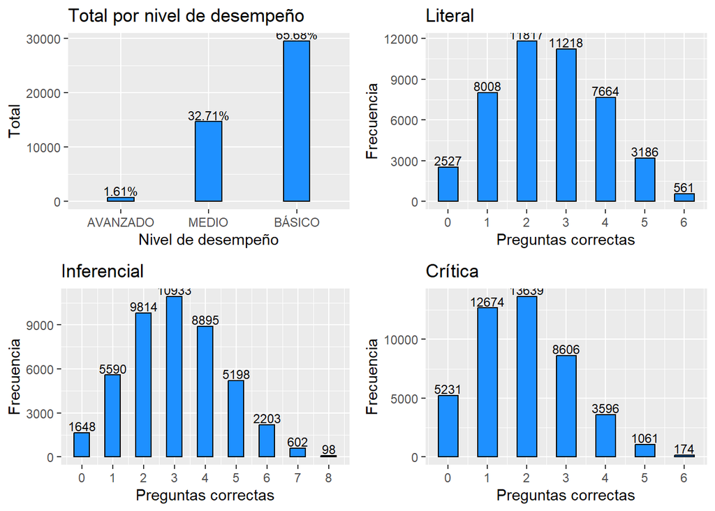

```r
grid.arrange(nivel,lit,inf,cri,ncol=2)
```

## PORCENTAJE DE EFICIENCIA POR COMPETENCIA EN SANTANDER

En este punto se pide revisar qué tan eficientes fueron los estudiantes en cada una de las competencias evaluadas. Para ello se deberá sumar el total de respuestas correctas dividida por el total de estudiantes.

```r
#Seleccionamos las variables de interés
compgen<-select(DATA_2,c(38:40))
```

```r
#Pasamos el objeto compgen a formato largo
?gather
compgen<-gather(compgen,COMPETENCIA,TOTAL)
```

```r
#Creamos nuestra tabla
compgen<-group_by(compgen,COMPETENCIA)
compgen1<-summarise(compgen,EFICIENCIA=sum(TOTAL)/length(TOTAL))
compgen1<-mutate(compgen1,PORCENTAJE=paste(round(EFICIENCIA,2),"%",sep = ""))
```

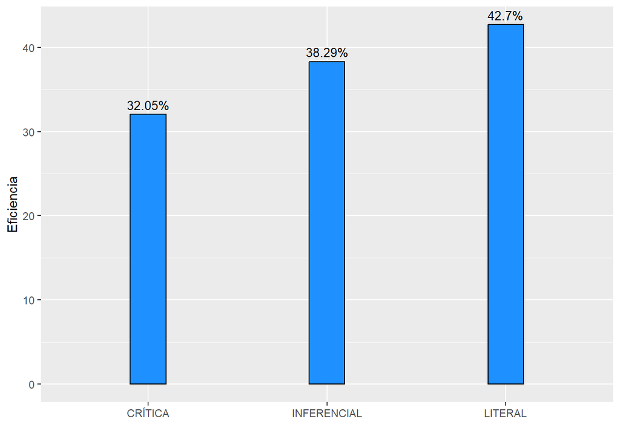

```r
#Realizamos el gráfico
ggplot(compgen1,aes(x=COMPETENCIA,y=EFICIENCIA))+
  geom_bar(stat="identity",fill="dodgerblue",width = 0.2,color="black")+
  labs(x="",y="Eficiencia")+
  geom_text(aes(label=PORCENTAJE),vjust=-0.5,size=3.5)
```

## NIVEL DE DESEMPEÑO POR PROVINCIA

Ahora se nos pide revisar el porcentaje de estudiantes en cada nivel de desempeño por provincia

```r
prov<-group_by(DATA_4,PROVINCIA,NIVEL)
prov<-summarise(prov,TOTAL=n())
prov<-mutate(prov,PORCENTAJE=paste(round(TOTAL*100/sum(TOTAL),2),
                                   "%",sep = ""))
prov$NIVEL<-factor(prov$NIVEL,levels = c("BÁSICO","MEDIO","AVANZADO"))
```

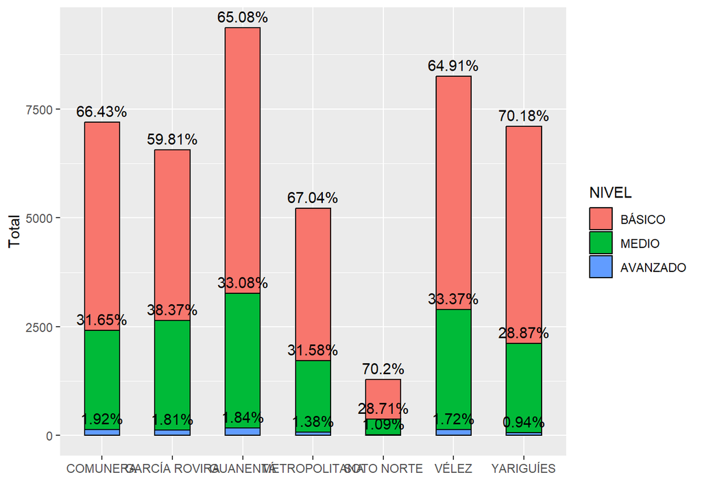

```r
ggplot(prov,aes(x=PROVINCIA,y=TOTAL,fill=NIVEL))+
  geom_bar(stat = "identity",width = 0.5,color="black")+
  labs(x="",y="Total")+
  geom_text(aes(label=PORCENTAJE),
            vjust=-0.5,size=3.8,position = position_stack())
```

## EFICICIENCIA POR PROVINCIA

```r
provcomp<-select(DATA_4,c(2,38:40))
```

```r
provcomp<-gather(provcomp,COMPETENCIA,EFICIENCIA,-1)
```

```r
provcomp<-mutate_all(provcomp,as.factor)
summary(provcomp)
```

```
##          PROVINCIA          COMPETENCIA      EFICIENCIA
##  COMUNERA     :21576   CRÍTICA    :44981   2      :35270
##  GARCÍA ROVIRA:19701   INFERENCIAL:44981   3      :30757
##  GUANENTÁ     :28095   LITERAL    :44981   1      :26272
##  METROPOLITANA:15675                       4      :20155
##  SOTO NORTE   : 3846                       5      : 9445
##  VÉLEZ        :24750                       0      : 9406
##  YARIGUÍES    :21300                       (Other): 3638
```

```r
provcomp1<-group_by(provcomp,PROVINCIA,COMPETENCIA,EFICIENCIA)
provcomp1<-summarise(provcomp1,TOTAL=n())
```

##Ejemplo Función spread

Vamos a tomar a usar un data frame con formato largo y lo transformamos en formato ancho.

```r
prueba<-select(DATA_4,c(2,38:40))
COD<-c(1:nrow(DATA_4))
prueba1<-bind_cols(prueba,COD)
```

Esta base muestra la cantidad de respuestas correctas por competencia y la provincia a la que pertenece el estudiante.

Está en formato ancho. Ahora vamos a pasarla a formato largo.

```r
prueba_largo<-gather(prueba1,COMPETENCIA,EFICIENCIA,-1,-5)
```

```r
prueba_ancho<-spread(prueba_largo,COMPETENCIA,EFICIENCIA)
```